# High school absence

Lovdip Singh

## Question of interest/goal of the study:

We want to find out if there is a difference between female and male high school junior students with regards to the number of days they are absent in one year. We also want to quantify this difference.

## Read in and inspect the data:

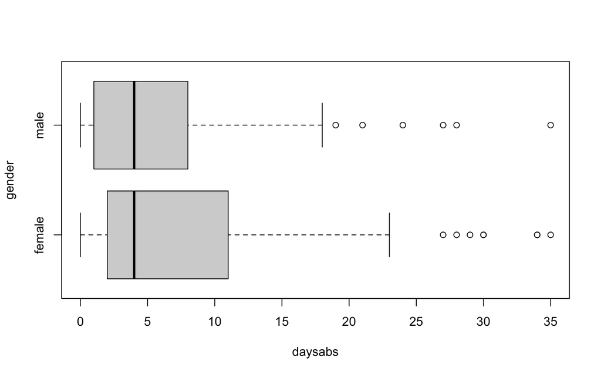

```r
daysabs.df=read.table("daysabs.txt",header=T)
daysabs.df$gender=as.factor(daysabs.df$gender)
plot(daysabs~gender,data=daysabs.df,horizontal=TRUE)
```

```r
table(daysabs.df$daysabs)
```

```
##
##  0  1  2  3  4  5  6  7  8  9 10 11 12 13 14 15 16 18 19 20 21 23 24 27 28 29
## 41 29 18 20 23 17 15 12  7 11  5  6  6  6  3  3  6  2  2  2  2  2  1  2  2  1
## 30 34 35
##  2  2  2
```

```r
var(daysabs.df$daysabs)
```

```
## [1] 55.26588
```

```r
summaryStats(daysabs~gender,data=daysabs.df)
```

```
##        Sample Size     Mean Median  Std Dev Midspread
## female         128 7.546875      4 8.213547         9
## male           122 5.549180      4 6.392276         7
```

## Model fitting

```r
daysabs.gfit <- glm(daysabs ~ gender, family=poisson, data = daysabs.df)
summary(daysabs.gfit)
```

```
##
## Call:
## glm(formula = daysabs ~ gender, family = poisson, data = daysabs.df)
##
## Deviance Residuals:
##     Min       1Q   Median       3Q      Max
## -3.8851  -2.4045  -0.9883   1.1758   8.3676
##
## Coefficients:
##             Estimate Std. Error z value Pr(>|z|)
## (Intercept)  2.02113    0.03217  62.818  < 2e-16 ***
## gendermale  -0.30748    0.05012  -6.135 8.53e-10 ***
## ---
## Signif. codes:  0 '***' 0.001 '**' 0.01 '*' 0.05 '.' 0.1 ' ' 1
##
## (Dispersion parameter for poisson family taken to be 1)
##
##     Null deviance: 1821.6  on 249  degrees of freedom
## Residual deviance: 1783.4  on 248  degrees of freedom
## AIC: 2524.3
##
## Number of Fisher Scoring iterations: 5
```

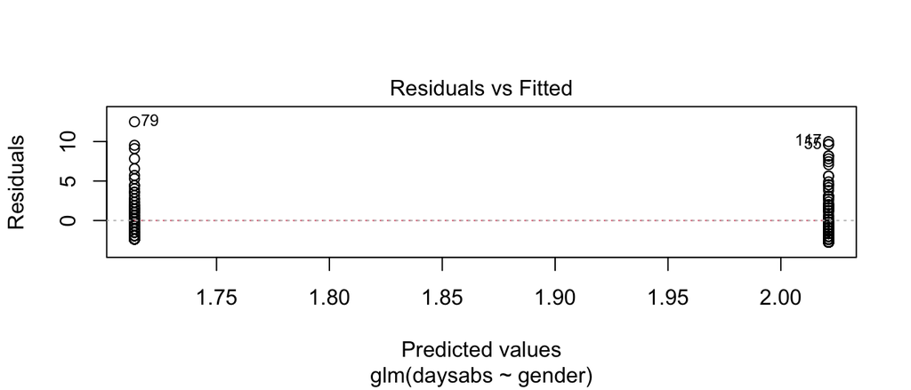

```r
plot(daysabs.gfit, which=1, lty=3)
```

```r
1 - pchisq(1783.4, 248)
```

```
## [1] 0
```

```r
daysabs.gfit2 <- glm(daysabs ~ gender, family=quasipoisson, data = daysabs.df)
summary(daysabs.gfit2)
```

```
##
## Call:
## glm(formula = daysabs ~ gender, family = quasipoisson, data = daysabs.df)
##
## Deviance Residuals:
##     Min       1Q   Median       3Q      Max
## -3.8851  -2.4045  -0.9883   1.1758   8.3676
##
## Coefficients:
##             Estimate Std. Error t value Pr(>|t|)
## (Intercept)  2.02113    0.09197  21.977   <2e-16 ***
## gendermale  -0.30748    0.14327  -2.146   0.0328 *
## ---
## Signif. codes:  0 '***' 0.001 '**' 0.01 '*' 0.05 '.' 0.1 ' ' 1
##
## (Dispersion parameter for quasipoisson family taken to be 8.170529)
##
##     Null deviance: 1821.6  on 249  degrees of freedom
## Residual deviance: 1783.4  on 248  degrees of freedom
## AIC: NA
##
## Number of Fisher Scoring iterations: 5
```

```r
#exponentiate for multiplicative effect
exp(confint(daysabs.gfit2)["gendermale",])
```

```
##     2.5 %    97.5 %
## 0.5537293 0.9718760
```

```r
#percentage change
100 * (1 - exp(confint(daysabs.gfit2)["gendermale",]))
```

```
##     2.5 %    97.5 %
## 44.627067  2.812397
```

## Method and Assumption Checks

As the response variable, days absent, is a count, we began by fitting a generalised linear model with a Poisson response distribution. We have one explanatory variable, gender, a categorical variable with 2 levels, female and male. The Poisson assumption was not satisfied in the initial model, as the chi-squared test had a P-value $\approx$ 0 indicating the model was not adequate. The residuals did not look random, so the family of the generalised linear model was changed to quasipoisson. This indicates that rather than $Var(X) = E(X)$, $Var(X) \propto E(X)$, which is true when looking at the summary statistics of the raw data. All model assumptions were satisfied, when using the quasipoisson family distribution to model this data set.

Our final model is:

$$log(\mu_i) = \beta_0 + \beta_1 \times genderMale_i$$

Where $\mu_i$ is the mean number of days absent for a junior high school student, $i$, and has a quasipoisson distribution with mean $\mu_i$. Also, $genderMale_i$ is a dummy variable which takes the value 1 if a the student is a male, otherwise 0.

## Executive Summary

It was of interest to explore the difference in number of days absent, in one year, between male and female junior students in high school.

We conclude that there is a difference between female and male student with regards to the number of day absent per year (P-value $\approx$ 0.03). We expect that the annual mean number of days absent to be between 44.6% and 2.8% less for male high school junior students, compared to female high school junior students.